# act_report

## Report: act_report

This project wrangle and analysed WeRAteDogs twitter data over three years period; 2015 to 2017. WeRateDog is a twitter page where followers get to post their Dogs in nice postures, sometimes in costumes or doing some activities for ratings. The rating is usually over ten (10) and the numerator can be anything above ten, usually in the range of ten (10) to fourteen (14). For images not dogs put up for rating, the phrase ‘we only rate dogs’ has been noticed to be used for such images to tell the user or users it is only dogs that must be put on the page and no ratings goes to such images. To gain insight from the twitter page, three data set was worked on including querying the twitter Application interface (API ).

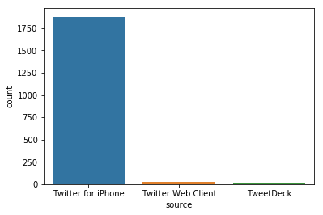

It is interesting to see most of the page engagements are coming from iphone mobile device with the source being over forty times more than other sources or device, this is fuhter revealed by barchart which shows iphone being the highest.

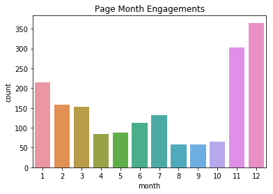

Another interesting thing is, there is more engagement towards the end of the year with most interaction being December a festive period.This is shown above

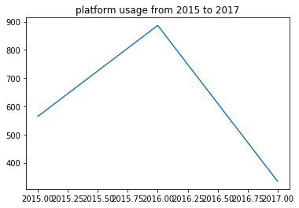

The third insight that was gained was user interaction with the page witnessed a sharp fall from 2016 without recovery throughout the period the analysis covered. This insight is supported by the line graph above which shows a sharp decline from 2016.